# Week 5 Workshop

Variable screening and Regression pitfalls

This week we have looked at a different method of determining a preferred model using AIC in conjunction with stepwise analysis. We have also started to look at some of the limitations and pitfalls that you need to be aware of when using and building multiple linear regression models.

The objective of this week’s workshop is to:

- Introduce you to conducting forward and backward stepwise analysis using the `step()` command.
- Check for multicollineairty using `ggpairs()`, `summary()` output and variance inflation factors (VIFs).
- Introduce you to the `vif()` command in the `car` library.

# 1 Samara example

In autumn, small winged fruit called samara fall off maple trees, spinning as they go. A forest scientist studied the relationship between how fast they fell (`Velocity`) and their “disk loading” (`Load`), a quantity based on their size and weight. The samara disk loading is related to the aerodynamics of helicopters. Also in the dataset is the `Tree` the measurment was taken from. Here we are going to treat `Tree` and a qualitative variable. The data are in the file `samara.csv`. Your task for today is to **determine if the rate of change in `Velocity` based on `Load` varies between `Tree`.**

Make sure you have your STAT210 or STAT410 project open and start a new R script. Name your new script something useful. EG Workshop 5 Regression pitfalls. Use the `options()` command from last week to set the number of significant figures and hide the significance stars in outputs. Finally, load the `samara.csv` data file and declare `Tree` as a factor.

**CHECK**

```r
options(digits=3, show.signif.stars=FALSE)
# read in data and store in object named samara.df
samara.df<-read.csv("data sets/samara.csv")
#Declare Tree as a factor
samara.df$Tree<-factor(samara.df$Tree)
```

## 1.1 Exploratory analysis

Produce an exploratory plot. What does this plot suggest about the research question?

**HINT:** Look at the slopes of each line. Do these slopes look parallel for all trees?

**CHECK**

We could start with a basic scatter plot of just `Load` and `Velocity` as shown below. However, because our research question is asking about difference in changes between trees, we should colour code for `Tree`.

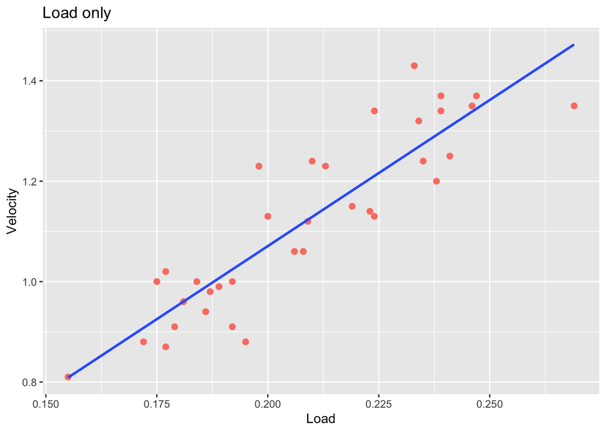

```r
library(ggplot2)
ggplot(data=samara.df, aes(x=Load, y=Velocity)) +
  geom_point(col="salmon", size=2) +
  geom_smooth(method="lm", se=FALSE)+
  labs(title="Load only")
```

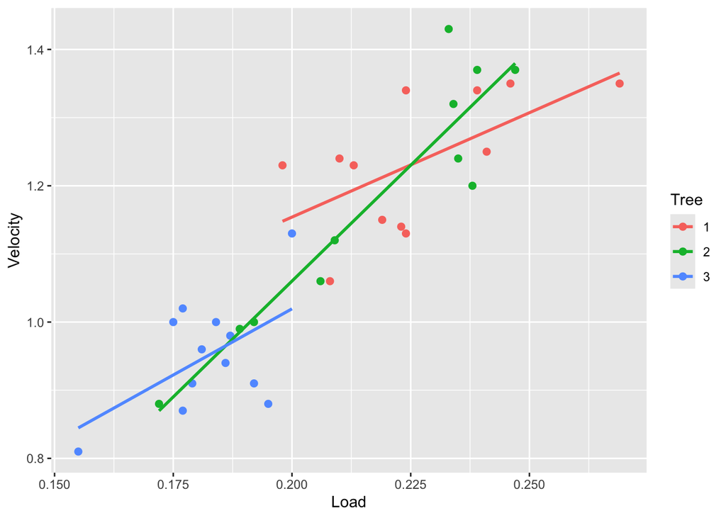

```r
ggplot(data=samara.df, aes(x=Load, y=Velocity, colour=Tree)) +
  geom_point(size=2) +
  geom_smooth(method="lm", se=FALSE)
```

There appears to be a positive, linear relationship between velocity and load. Looking at this change between the trees, the change for tree 2 appears to be faster (steeper slope) than the change in tree 1 and 3 (shallower slopes). This indicates that the influence of velocity of falling samara on load may be different depending on different trees. EG we might want to test an interaction between `Tree` and `Load`.

Having multiple groups of scatter and lines overlap like above is a little messy. So lets introduce a new part of the command in `ggplot()`, `facet_grid()`. What the command `facet_grid()` does is to separate your scatter and your lines into different panels based on some qualitative variable. In this case, `Tree`.

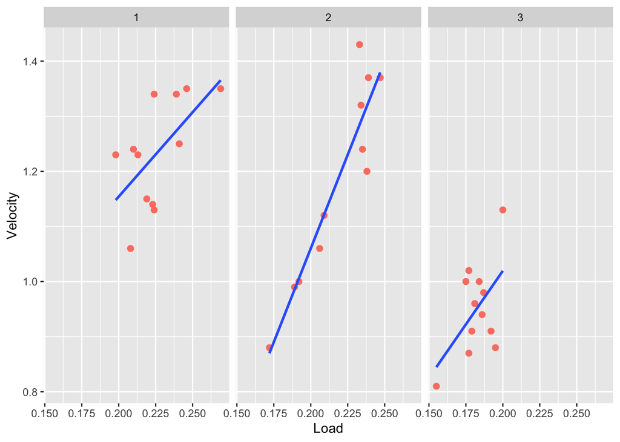

```r
library(ggplot2)
ggplot(data=samara.df, aes(x=Load, y=Velocity)) +
  geom_point(col="salmon", size=2) +
  facet_grid(~Tree)+
  geom_smooth(method="lm", se=FALSE)
```

## 1.2 Fit models and determine the preferred model

Lets look at three different model options to explain the relationship between `Velocity`, `Load` and `Tree`. From the variables we have to describe `Velocity`, we could fit:

1. `Velocity` changes based on `Load` and that this change is the same across all `Tree`s. EG the first plot.

$\hat{Velocity} = \beta_0+\beta_1Load$

2. `Velocity` changes based on `Load` and `Tree` has some additive effect. EG just the intercepts for the lines of the different trees change but the slopes are the same.

$\hat{Velocity} = \beta_0+\beta_1Load+\beta_2Tree_{2}+\beta_3Tree_{3}$

3. `Velocity` changes based on `Load` and this change is different based on `Tree`. EG the slopes and intercepts of the lines for each tree change.

$\hat{Velocity} = \beta_0+\beta_1Load+\beta_2Tree_{2}+\beta_3Tree_{3}+\beta_4Load*Tree_2+\beta_5Load*Tree_3$

**Note:** We have decided not to fit polynomial terms as the relationship does not look bendy from the plots. We have also not fit a `Tree` only model, as from the plot it does appear that `Velocity` is changing in response to `Load`.

Lets define these in Rstudio:

```r
mod1<-lm(Velocity~Load, data=samara.df)
mod2<-lm(Velocity~Load+Tree, data=samara.df)
mod3<-lm(Velocity~Load*Tree, data=samara.df)
```

### 1.2.1 Comparing models using ANOVA() (p-values)

We can compare these three models using ANOVA:

```r
anova(mod1, mod2, mod3)
```

```
## Analysis of Variance Table
##
## Model 1: Velocity ~ Load
## Model 2: Velocity ~ Load + Tree
## Model 3: Velocity ~ Load * Tree
##   Res.Df   RSS Df Sum of Sq    F Pr(>F)
## 1     33 0.215
## 2     31 0.203  2    0.0113 0.99   0.38
## 3     29 0.166  2    0.0379 3.33   0.05
```

Remember that anova compare increasingly complex models. Here we can see that Model 2 does not explain signifcantly more variation in `Velocity` than model 1 (p=0.38>0.5). Also that model 3 does not explain signifcantly more variation in `Velocity` than model 2 (p=0.05>0.05) (Note the very close p-value!). This output suggests that change in `Velocity` based on `Load` is not different across the three trees.

## 1.3 Comparing models using AIC and stepwise regression

Lets use stepwise regression to see if the interaction should be retained in the model.

AIC is a numerical metric of assessing model fit. It is calculated by trading off between model complexity and model selection. It maximises the explanation of the variation in the response while minimising the number of parameters. OR it gives the best fit to the data while using the least number of parameters. When comparing models using AIC, the model with the smallest value is the model which has the best fit to the data. In general if the difference between two models is less than 2, we can say that the two models are basically indistinguishable.

There are some good points of view on the different methods of model comparison that you could read [here](https://royalsocietypublishing.org/doi/full/10.1098/rsbl.2019.0174). NOTE that we do not cover Bayes factor in this unit.

In the lectures we used stepwise regression based on the principles of AIC to find a preferred model. Stepwise regression adds or removes individual parameters in a step by step procedure. AIC is used to determine if a 1 parameter more complex model is better than the reference model. The stepwise procedure stops when adding or removing a parameter does not lower the AIC any further.

Lets look at this using the `samara.df` data. Here we have performed a forward stepwise procedure. EG adding parameters.

The code is broken into 4 lines of code. The first two lines of code define the simplest and most complex model that you want to test. In this example, we want our simplest model to be an intercept only model (defined with the `~1`) and our most complex to be an interaction model between `Tree` and `Load`. The third line of code defines the starting model. Becuase we are running a forward stepise, this starting model needs to be an intercept only model. The final line of code runs the stepwise procedure using the scope we defined in lines 1 and 2 and the starting model from lines 3. We also specify the direction here as “forward”.

```r
formL<-formula(~1, data=samara.df)
formU<-formula(~Load*Tree, data=samara.df)
start.mod.f<-lm(Velocity~1, data=samara.df)
step.mod.f<-step(start.mod.f, scope=list(upper=formU, lower=formL), direction="forward")
```

```
## Start:  AIC=-120
## Velocity ~ 1
##
##        Df Sum of Sq   RSS  AIC
## + Load  1     0.844 0.215 -174
## + Tree  2     0.539 0.519 -141
## <none>              1.058 -120
##
## Step:  AIC=-174
## Velocity ~ Load
##
##        Df Sum of Sq   RSS  AIC
## <none>              0.215 -174
## + Tree  2    0.0113 0.203 -172
```

There are two steps to our stepwise procedure. In the first step, the AIC for the starting (intercept only) model is -120. The procedure has determined that a model including `Load` (AIC=-174) or `Tree` (AIC=-141) will reduce the AIC. However, since including `Load` reduced the AIC more than including `Tree`, the procedure has decided to add `Load`. In the second step, the model with `Load` has an AIC of -174. If `Tree` was to be added to the model, then the AIC value would increase to -172. In this case the procedure stops and determines that a model with just `Load` in it is the model that maximises the variation in the data while retaining the least number of parameters.

There is a drawback with this method though. With the additive nature of the procedure, some terms may not be tested. In this example, we could not check the interaction between `Load` and `Tree` because the stepwise procedure determined that adding `Tree` would increase the AIC. Because the main effects of `Tree` and `Load were not both in the model, the stepwise procedure could test the addition of the interaction. If we want to specifically check the interaction, we should run a backwards stepwise instead.

**NOTE:** We can reuse the first two lines of code from the forward stepwise because we haven’t changed the bounds of our model. We do need to change our starting model to the most complex model because with a backwards stepwise we are taking parameters out. Also the direction has changed to “backward”

```r
start.mod.b<-lm(Velocity~Load*Tree, data=samara.df)
step.mod.b<-step(start.mod.b, scope=list(upper=formU, lower=formL), direction="backward")
```

```
## Start:  AIC=-175
## Velocity ~ Load * Tree
##
##             Df Sum of Sq   RSS  AIC
## <none>                   0.166 -175
## - Load:Tree  2    0.0379 0.203 -172
```

Here we just have the one step testing the interaction term. Removing the interaction term increases the AIC, which indicates that the interaction term should remain in the model. Despite the addition of the extra parameters, this model fits the `Velocity` data better.

Using the two different stepwise procedures has now determined that two separate models are a good fit to the data. Is there a way to compare which of these two might be the better fit?

Unlike ANOVA() where you need to compare models that differ by one parameter, AIC can be used to compare very different models. Lets calculate AIC for both models and see which has the smallest AIC value.

**NOTE:** The way R calculates the AIC value in `step()` differs slightly to how it calculates the AIC value in `AIC()`. However, the concept of using the smallest AIC to determine the preferred models remains the same. If you want to know more about the difference in AIC calculation methods, you can run `?extractAIC`.

```r
AIC(step.mod.b, step.mod.f)
```

```
##            df   AIC
## step.mod.b  7 -74.1
## step.mod.f  3 -72.9
```

```r
#alternatively
AIC(mod1,mod3)
```

```
##      df   AIC
## mod1  3 -72.9
## mod3  7 -74.1
```

The model determined by the backwards stepwise regression (or the third model) has the smallest AIC between them, so the model with the interaction is the better fit when modelling `Velocity`.

## 1.4 Check conditions of the model

We should check the conditions of a multiple linear regression and we can do this the same way as in previous weeks.

**CHECK**

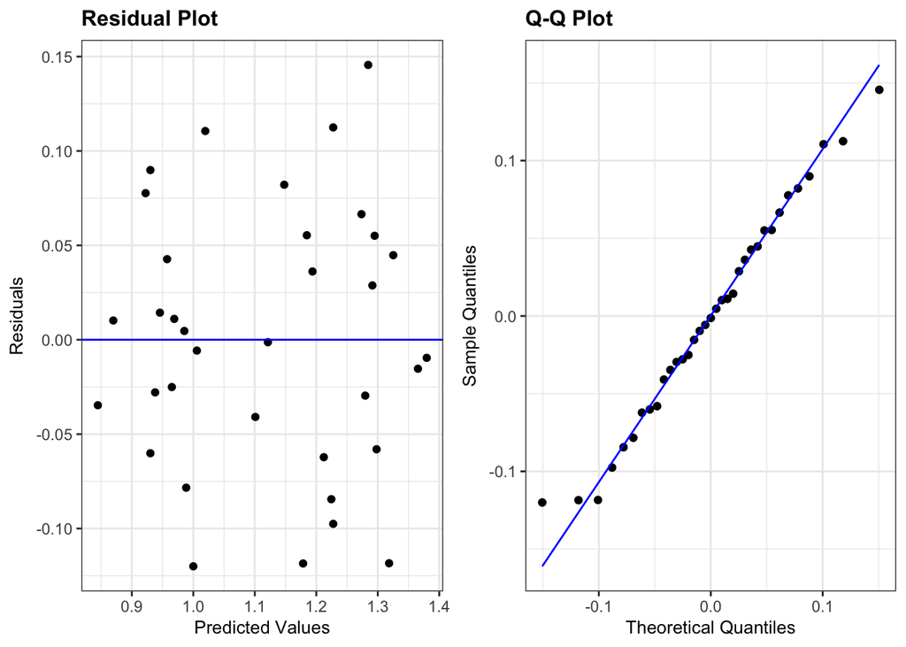

```r
library(ggResidpanel)
resid_panel(step.mod.b, plots=c("resid","qq"))
```

The scatter in the q-q plot is relatively straight, indicating the tha residuals are normally distributed. The width of the scatter is the same distance from the 0 line in the residual vs fitted plot indicating that residuals have a mean of 0. There is also no indication of fanning in the scatter, so residuals have constant variance. All conditions of a linear regression have been met. <>

## 1.5 Write an informative conclusion

Since we have used AIC and stepwise regression to determine our model, we no longer talk about any p-values. This means we no longer test if the model is “useful” overall or if the parameters themselves are useful using p-values. We can still use the coefficients to state the regression equation and the confidence intervals to describe the change in `Velocity` based on `Load` and `Tree` (if applicable). Other comments we can make include:

- Which parameters were important in modelling `Velocity`.
- Answer the research question with regards to the interaction between `Load` and `Tree`. EG *Does change in `Velocity` based on `Load` differ between different trees?*
- If the conditions of the model have been met.
- Interpret the Adjusted R-squared.

```r
summary(step.mod.b)
```

```
##
## Call:
## lm(formula = Velocity ~ Load * Tree, data = samara.df)
##
## Residuals:
##     Min      1Q  Median      3Q     Max
## -0.1200 -0.0495 -0.0013  0.0499  0.1456
##
## Coefficients:
##             Estimate Std. Error t value Pr(>|t|)
## (Intercept)    0.541      0.263    2.06    0.049
## Load           3.063      1.160    2.64    0.013
## Tree2         -0.841      0.336   -2.50    0.018
## Tree3         -0.299      0.445   -0.67    0.508
## Load:Tree2     3.734      1.500    2.49    0.019
## Load:Tree3     0.820      2.284    0.36    0.722
##
## Residual standard error: 0.0755 on 29 degrees of freedom
##   (1 observation deleted due to missingness)
## Multiple R-squared:  0.844,  Adjusted R-squared:  0.817
## F-statistic: 31.3 on 5 and 29 DF,  p-value: 7.66e-11
```

```r
confint(step.mod.b)
```

```
##                2.5 % 97.5 %
## (Intercept)  0.00307  1.080
## Load         0.69060  5.435
## Tree2       -1.52722 -0.154
## Tree3       -1.20972  0.612
## Load:Tree2   0.66645  6.802
## Load:Tree3  -3.85013  5.491
```

A model containing `Load`, `Tree` and their interaction is the best fit to model samara `Velocity`. This indicates that the change in `Velocity` based on `Load` is different for different trees.

The final model equation is:

$\hat{Velocity}=0.541+3.1(Load)-0.8(Tree_{2})-0.3(Tree_{3})+3.7(Load*Tree_2)+0.8(Load*Tree_3)$

The model explains 81.7% of the variability in `Velocity`.

From the confidence intervals we can say:

The change in `Velocity` based on `Load` is between 0.7 and 6.8 faster for tree 2 and between 3.9 slower or 5.5 faster for tree 3 when compared to tree 1. Note the CI for tree 3 contains 0, which indicates that potentially there is no difference in `Velocity` change between tree 1 and tree 3. Looking at the plot, this supports what we observed, that the slope for tree 1 and tree 3 are similar but that the slope for tree 2 is steeper.

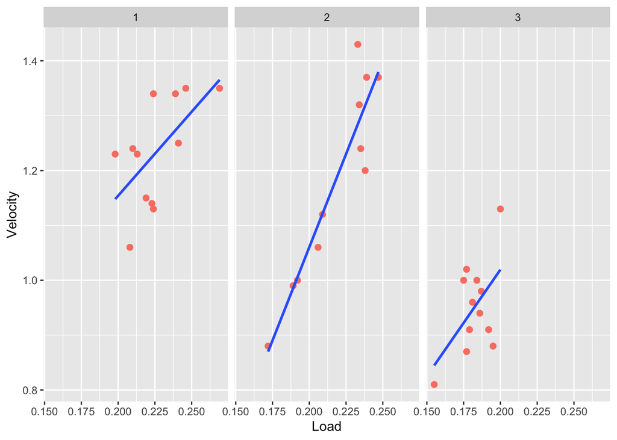

All conditions of a linear regression were met.

# 2 Perch example

The `Weight` (g), `Length` (cm) and `Width` (cm) of a sample of 56 perch were recorded. Also contained in the data set are the length class (`L`) and weight class (`Wd`) of the perch as well as the observation number (`Obs`). For this example, we will use the quantitative versions of weight and length.

**Source**: STAT2: Building Models for a World of Data, A. R. Cannon (2013), W. H. Freeman [Ed.].

Read in the `Perch.csv` data.

**CHECK**

```r
# read in data and store in object named samara.df
per.df<-read.csv("data sets/Perch.csv")
```

## 2.1 Exploratory analysis

Produce a pairs plot using `ggpairs()`.

**CHECK**

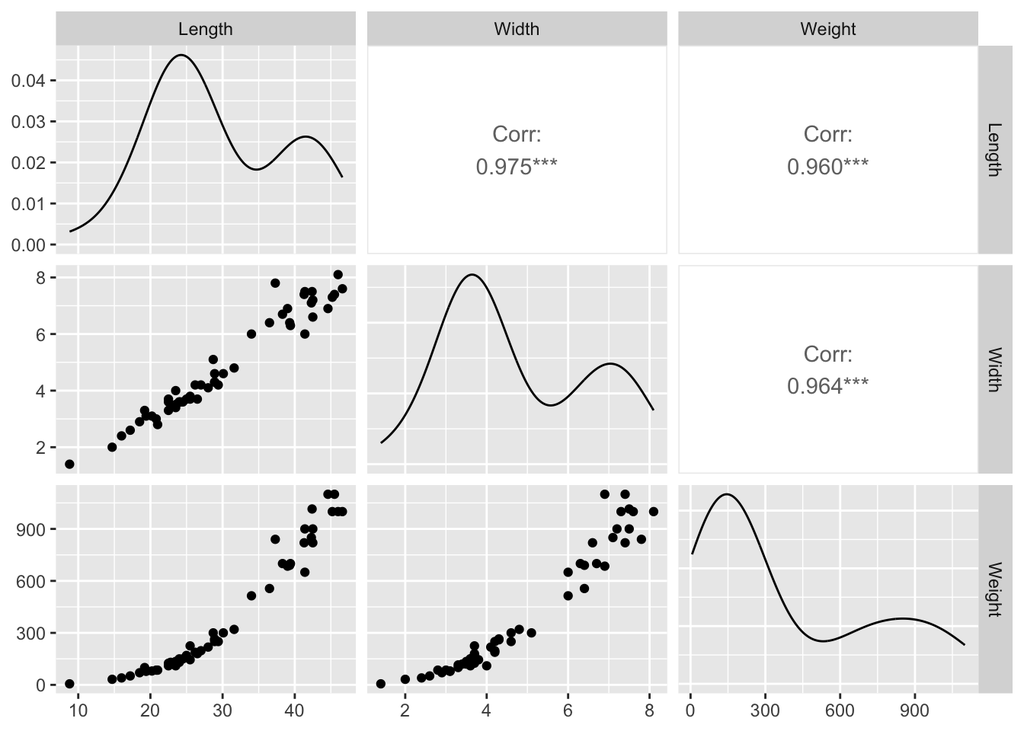

```r
library(GGally)
ggpairs(per.df, columns=c(3,5,2))
```

We have discussed interpreting the `ggpairs()` plot for this data in previous weeks, so we won’t do that again here.

## 2.2 Check for multicollinearity

When data has multiple predictor variables with strong correlations, we should check for multicollinearity. Multicollinearity is problematic in multiple linear regression as inference drawn from models that exhibit multicollinearity is unreliable. From the lectures, we know there are 4 indicators that we can check for multicollinearity:

1. Strong, significant correlations between predictors.
2. Many individual p-values for the variables when the global utility p-value is significant.
3. Beta coefficients going in the opposite direction to what is expected from their correlation coefficient with the response. EG if the the correlation between the predictor is positive, but the beta coefficient is negative.
4. A variance inflation factor (VIF) greater than 10.

From the correlations in the `ggpairs()`, there is a strong correlation between `Length` and `Width`(r=0.975). Which indicates potential collinearity.

Looking at the summary output for the main effects model, both of the p-values for the individual beta coefficients are significant. Also neither of beta coefficients for `Length` or `Width` are in the opposite directions to what was expected.

```r
per.mod<-lm(Weight~Length+Width, data=per.df)
summary(per.mod)
```

```
##
## Call:
## lm(formula = Weight ~ Length + Width, data = per.df)
##
## Residuals:
##    Min     1Q Median     3Q    Max
## -113.9  -59.0  -23.3   30.9  299.9
##
## Coefficients:
##             Estimate Std. Error t value Pr(>|t|)
## (Intercept)  -578.76      43.67  -13.25  < 2e-16
## Length         14.31       5.66    2.53  0.01447
## Width         113.50      30.26    3.75  0.00044
##
## Residual standard error: 88.7 on 53 degrees of freedom
## Multiple R-squared:  0.937,  Adjusted R-squared:  0.935
## F-statistic:  396 on 2 and 53 DF,  p-value: <2e-16
```

Finally we can calculate the VIF values with:

```r
library(car)
vif(per.mod)
```

```
## Length  Width
##   20.3   20.3
```

Both `Length` and `Width` all have a VIF value >10.

All together, there is strong collinearity in this dataset. For this example, we only want to include either `Length` or `Width` in the model not both.

## 2.3 Fit polynomial model for `Width` and compare to polynomial model for `Length`

From previous weeks looking at this dataset, we know that a second order polynomial model is useful in explaining perch `Weight`. Lets fit a second order polynomial model for `Length` and for `Width` and use AIC to compare the two. The two models we are comparing are:

$\hat{Weight} = \beta_0+\beta_1Length+\beta_2Length^2$

$\hat{Weight} = \beta_0+\beta_1Width+\beta_2Width^2$

```r
per.weight<-lm(Weight~Width+I(Width^2), data=per.df)
per.length<-lm(Weight~Length+I(Length^2), data=per.df)
AIC(per.weight, per.length)
```

```
##            df AIC
## per.weight  4 647
## per.length  4 617
```

The AIC value is lowest for the polynomial model for `Length` (AIC=617), indicating that this model fits the data best of the two.

## 2.4 Check conditions of the model

We should check the conditions of a multiple linear regression and we can do this the same way as in previous weeks.

**CHECK**

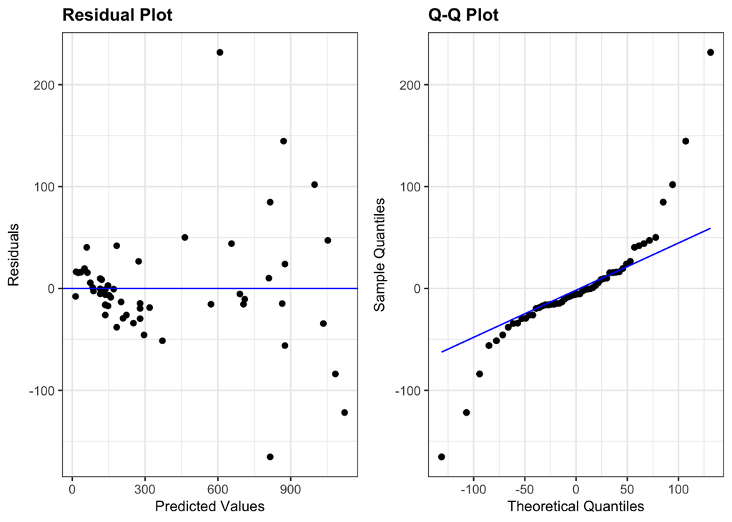

```r
resid_panel(per.length, plots=c("resid","qq"))
```

The scatter in the Q-Q plot has major deviations from the line on either ends indicating that the residuals are probably not normally distributed.

The scatter in the residual plot is symmetrical on either side of the 0 line, so the residuals have a mean of 0. The width of the scatter does appear narrower on the left hand side of the plot than on the right hand side, indicating non-constant variance. <>

## 2.5 Write an informative conclusion

Calculate the regression coefficients and confidence intervals for the second order polynomial model for `Length`. Interpret the output and create a plot to represent the relationship between `Length` and perch `Weight`.

**CHECK**

```r
summary(per.length)
```

```
##
## Call:
## lm(formula = Weight ~ Length + I(Length^2), data = per.df)
##
## Residuals:
##     Min      1Q  Median      3Q     Max
## -165.30  -18.97   -5.75   15.65  231.69
##
## Coefficients:
##             Estimate Std. Error t value Pr(>|t|)
## (Intercept) 128.3453    78.7787    1.63  0.10920
## Length      -21.0239     5.4177   -3.88  0.00029
## I(Length^2)   0.9086     0.0869   10.46  1.7e-14
##
## Residual standard error: 57 on 53 degrees of freedom
## Multiple R-squared:  0.974,  Adjusted R-squared:  0.973
## F-statistic:  997 on 2 and 53 DF,  p-value: <2e-16
```

```r
confint(per.length)
```

```
##               2.5 % 97.5 %
## (Intercept) -29.665 286.36
## Length      -31.890 -10.16
## I(Length^2)   0.734   1.08
```

$\hat{Weight} = 128.35-21.02Length+0.91Length^2$

The model explains 97.3% of the variation in perch `Weight`.

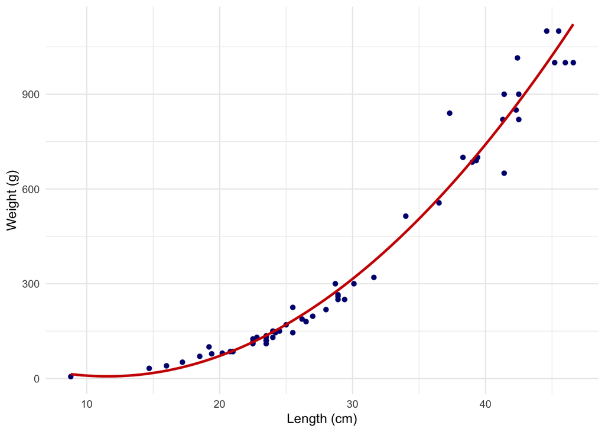

```r
ggplot(data=per.df, aes(x=Length, y=Weight))+
  geom_point(col="Navy")+
  geom_smooth(method="lm", formula=y~poly(x,2), col="red3", se=F)+
  labs(x="Length (cm)", y="Weight (g)")+
  theme_minimal()
```

# 3 Monarch butterfly example

Researchers have conducted a study on why monarch butterflies are declining in the western parts of North America. The data set `butterfly.csv` contains information about monarch butterfly population changes (as a finite rate of increase in western monarch population from the previous year to the current one,`LAMBDA`) from 1982 to 2016. A number of environmental variables are also recorded in the data set:

- `YEAR`: The year with which subsequent fields are associated.
- `EST.DEV`: Percentage estimates of land development around monarch overwintering sites on the coast of California.
- `PDSI_ALL`: Palmer Drought Severity Index averaged from January to September across all western regions in the analysis. It is a standardized index that generally spans -10 (dry) to +10 (wet).
- `TMAX_ALL`: Average monthly maximum temperature in degrees Celsius (oC ) from June – August across all western regions in the analysis.
- `CDD_ALL`: Days in which the average temperature exceeded 18 C from June – August across all western regions in the analysis.
- `GLY_CA_AG`: The summed amount of active ingredient (glyphosate—all formulations) applied for agricultural applications in California for the associated year (lbs.).
- `GLY_CA_NON.AG`: The amount of active ingredient (glyphosate—all formulations) applied for non-agricultural applications in California for the associated year (lbs.).
- `SOI`: An indicator of the El Nino Southern Oscillation (ENSO) state based on sea level pressure at two stations. Negative values of SOI represents below-normal air pressure at Tahiti and above-normal air pressure at Darwin typical of El Niño episodes.
- `MEI`: An indicator of the El Nino Southern Oscillation (ENSO) state based on sea level pressure, sea surface temperature, zonal and meridional components of the surface wind, and outgoing longwave radiation. Large positive MEI values indicate the occurrence of El Niño conditions, while large negative MEI values indicate the occurrence of La Niña conditions

**Source:** Crone, E.E., Pelton, E.M., Brown, L.M., Thomas, C.C. & Schultz, C.B. (2019). Why are monarch butterflies declining in the West? Understanding the importance of multiple correlated drivers. Ecological Applications, 29(7), 1-13.

Read in the `buttefly.csv` data.

**CHECK**

```r
# read in data and store in object named samara.df
butterfly.df<-read.csv("data sets/butterfly.csv")
```

## 3.1 Exploratory analysis

Since we have a number of quantitative variables, lets produce a pairs plot using `ggpairs()`.

Note the extra commands in the code, which have been added to modify the size of the text. The `upper = list(continuous = wrap('cor', size=2))` changes the size of the correlation values, the `axis.text=element_text(size=3)` changes the size of the axis tick values and the `strip.text.x = element_text(size=4), strip.text.y = element_text(size=4)` changes the size of the variable labels on the x and y axis respectively. Feel free to change the size value on any of these to match with you plot.

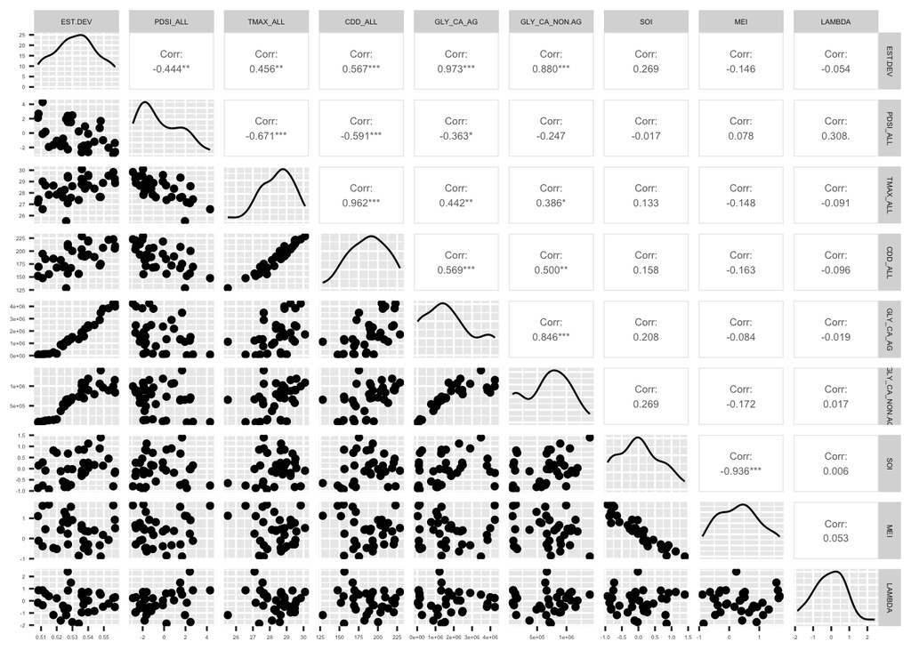

```r
library(GGally)
ggpairs(butterfly.df, columns=c(3:10, 2), upper = list(continuous = wrap('cor', size=2)))+
  theme(axis.text=element_text(size=3), strip.text.x = element_text(size=4), strip.text.y = element_text(size=4))
```

## 3.2 Check for multicollinearity

Lets check for multicollinearity in the `butterfly.csv` data.

Looking at the summary output for the main effects model, none of the p-values for the individual beta coefficients are significant. However, the global utility p-value is >0.05, so this is inconclusive.

```r
mod.bfly<-lm(LAMBDA~EST.DEV+PDSI_ALL+TMAX_ALL+CDD_ALL+GLY_CA_AG+GLY_CA_NON.AG+SOI+MEI, data=butterfly.df)
summary(mod.bfly)
```

```
##
## Call:
## lm(formula = LAMBDA ~ EST.DEV + PDSI_ALL + TMAX_ALL + CDD_ALL +
##     GLY_CA_AG + GLY_CA_NON.AG + SOI + MEI, data = butterfly.df)
##
## Residuals:
##     Min      1Q  Median      3Q     Max
## -2.1978 -0.5380  0.0919  0.4898  2.0171
##
## Coefficients:
##                Estimate Std. Error t value Pr(>|t|)
## (Intercept)   -2.73e+01   4.94e+01   -0.55     0.59
## EST.DEV        5.63e+00   8.09e+01    0.07     0.95
## PDSI_ALL       2.88e-01   1.85e-01    1.56     0.13
## TMAX_ALL       1.10e+00   8.89e-01    1.24     0.23
## CDD_ALL       -3.88e-02   3.57e-02   -1.09     0.29
## GLY_CA_AG      1.25e-07   6.95e-07    0.18     0.86
## GLY_CA_NON.AG  2.78e-09   1.12e-06    0.00     1.00
## SOI            7.14e-04   9.88e-01    0.00     1.00
## MEI            5.39e-02   8.02e-01    0.07     0.95
##
## Residual standard error: 0.962 on 26 degrees of freedom
## Multiple R-squared:  0.169,  Adjusted R-squared:  -0.0869
## F-statistic: 0.66 on 8 and 26 DF,  p-value: 0.721
```

Finally we can calculate the VIF values with:

```r
library(car)
vif(mod.bfly)
```

```
##       EST.DEV      PDSI_ALL      TMAX_ALL       CDD_ALL     GLY_CA_AG
##         48.81          4.61         28.82         28.18         30.04
## GLY_CA_NON.AG           SOI           MEI
##          6.34         14.09         12.83
```

`EST.DEV`, `TMAX_ALL`, `CDD_ALL`, `GLY_CA_AG`, `SOI` and `MEI` all have a VIF value >10.

All together, there is strong multicollinearity between the varaibles in this data set.

## 3.3 Look at pairs of strongly correlated variables to pick a subset of variables

Lets pick a subset of variables to work with, rather than fitting all of them. Then we can fit a model with just these variables and see if there is still an issue with multicollinearity. The predictors that are most strongly correlated with `LAMBDA` are `EST.DEV` (r=-0.054), `PDSI_ALL` (r=0.308), `TMAX_ALL` (r=-0.091), `CDD_ALL` (r=-0.096), and `MEI` (r=0.053). `CDD_ALL` and `TMAX_ALL` have a very strong correlation, so lets only include one of these two as well. The proposed subset of variables are: `EST.DEV`, `PDSI_ALL`, `CDD_ALL`, and `MEI`.

**NOTE:** `TMAX_ALL` was removed because it had the lower correlation with `LAMBDA` when compared to `CDD_ALL`.

```r
mod.blfy.2<-lm(LAMBDA~EST.DEV+PDSI_ALL+CDD_ALL+MEI, data=butterfly.df)
summary(mod.blfy.2)
```

```
##
## Call:
## lm(formula = LAMBDA ~ EST.DEV + PDSI_ALL + CDD_ALL + MEI, data = butterfly.df)
##
## Residuals:
##     Min      1Q  Median      3Q     Max
## -2.3100 -0.4558 -0.0491  0.5633  2.0912
##
## Coefficients:
##             Estimate Std. Error t value Pr(>|t|)
## (Intercept) -3.16633    6.80567   -0.47    0.645
## EST.DEV      4.46062   13.75347    0.32    0.748
## PDSI_ALL     0.19285    0.10433    1.85    0.074
## CDD_ALL      0.00415    0.00891    0.47    0.645
## MEI          0.06235    0.21916    0.28    0.778
##
## Residual standard error: 0.926 on 30 degrees of freedom
## Multiple R-squared:  0.112,  Adjusted R-squared:  -0.00669
## F-statistic: 0.944 on 4 and 30 DF,  p-value: 0.452
```

```r
vif(mod.blfy.2)
```

```
##  EST.DEV PDSI_ALL  CDD_ALL      MEI
##     1.52     1.58     1.89     1.03
```

Using only a subset of variables; `EST.DEV`, `PDSI_ALL`, `CDD_ALL`, and `MAI` has removed the multicollinearity problem. Now we can think about testing some second order interactions. We won’t fit polynomial terms to this data because the exploratory analysis does not suggest a polynomial relationship between any of the predictors and `LAMBDA`.

## 3.4 Use AIC to find a model

Lets use AIC in order to look for a well fitting model. In this example we will use both forward and backward stepwise.

```r
formL<-formula(~1)
formU<-formula(~(EST.DEV+PDSI_ALL+CDD_ALL+MEI)^2)
start.mod.bfly<-lm(LAMBDA~(EST.DEV+PDSI_ALL+CDD_ALL+MEI)^2, data=butterfly.df)
step.mod.blfy<-step(start.mod.bfly, scope=list(upper=formU, lower=formL), direction="backward")
```

```
## Start:  AIC=7.24
## LAMBDA ~ (EST.DEV + PDSI_ALL + CDD_ALL + MEI)^2
##
##                    Df Sum of Sq  RSS  AIC
## - EST.DEV:MEI       1     0.048 23.0 5.31
## - EST.DEV:CDD_ALL   1     0.084 23.0 5.37
## - PDSI_ALL:CDD_ALL  1     0.188 23.1 5.53
## - EST.DEV:PDSI_ALL  1     0.408 23.4 5.86
## - CDD_ALL:MEI       1     0.660 23.6 6.23
## <none>                          23.0 7.24
## - PDSI_ALL:MEI      1     2.210 25.2 8.46
##
## Step:  AIC=5.31
## LAMBDA ~ EST.DEV + PDSI_ALL + CDD_ALL + MEI + EST.DEV:PDSI_ALL +
##     EST.DEV:CDD_ALL + PDSI_ALL:CDD_ALL + PDSI_ALL:MEI + CDD_ALL:MEI
##
##                    Df Sum of Sq  RSS  AIC
## - EST.DEV:CDD_ALL   1     0.071 23.1 3.42
## - PDSI_ALL:CDD_ALL  1     0.204 23.2 3.62
## - EST.DEV:PDSI_ALL  1     0.364 23.4 3.86
## - CDD_ALL:MEI       1     1.126 24.1 4.99
## <none>                          23.0 5.31
## - PDSI_ALL:MEI      1     2.175 25.2 6.48
##
## Step:  AIC=3.42
## LAMBDA ~ EST.DEV + PDSI_ALL + CDD_ALL + MEI + EST.DEV:PDSI_ALL +
##     PDSI_ALL:CDD_ALL + PDSI_ALL:MEI + CDD_ALL:MEI
##
##                    Df Sum of Sq  RSS  AIC
## - PDSI_ALL:CDD_ALL  1     0.194 23.3 1.72
## - EST.DEV:PDSI_ALL  1     0.336 23.4 1.93
## - CDD_ALL:MEI       1     1.057 24.1 2.99
## <none>                          23.1 3.42
## - PDSI_ALL:MEI      1     2.108 25.2 4.48
##
## Step:  AIC=1.72
## LAMBDA ~ EST.DEV + PDSI_ALL + CDD_ALL + MEI + EST.DEV:PDSI_ALL +
##     PDSI_ALL:MEI + CDD_ALL:MEI
##
##                    Df Sum of Sq  RSS  AIC
```

[output cut: 37 more lines]

```
##
## Step:  AIC=-4.17
## LAMBDA ~ PDSI_ALL + MEI
##
##            Df Sum of Sq  RSS   AIC
## - MEI       1     0.024 26.2 -6.14
## <none>                  26.2 -4.17
## - PDSI_ALL  1     2.694 28.9 -2.74
##
## Step:  AIC=-6.14
## LAMBDA ~ PDSI_ALL
##
##            Df Sum of Sq  RSS   AIC
## <none>                  26.2 -6.14
## - PDSI_ALL  1      2.75 28.9 -4.64
```

```r
summary(step.mod.blfy)
```

```
##
## Call:
## lm(formula = LAMBDA ~ PDSI_ALL, data = butterfly.df)
##
## Residuals:
##     Min      1Q  Median      3Q     Max
## -2.1027 -0.4544  0.0478  0.6100  2.0593
##
## Coefficients:
##             Estimate Std. Error t value Pr(>|t|)
## (Intercept)  -0.0134     0.1543   -0.09    0.931
## PDSI_ALL      0.1486     0.0798    1.86    0.072
##
## Residual standard error: 0.891 on 33 degrees of freedom
## Multiple R-squared:  0.095,  Adjusted R-squared:  0.0676
## F-statistic: 3.46 on 1 and 33 DF,  p-value: 0.0716
```

```r
formU<-formula(~(EST.DEV+PDSI_ALL+CDD_ALL+MEI)^2)
mod.step.bfly2<-step(lm(LAMBDA~1, data=butterfly.df), scope=list(lower=formL, upper=formU), direct="forward")
```

```
## Start:  AIC=-4.64
## LAMBDA ~ 1
##
##            Df Sum of Sq  RSS   AIC
## + PDSI_ALL  1     2.751 26.2 -6.14
## <none>                  28.9 -4.64
## + CDD_ALL   1     0.264 28.7 -2.96
## + EST.DEV   1     0.083 28.9 -2.74
## + MEI       1     0.081 28.9 -2.74
##
## Step:  AIC=-6.14
## LAMBDA ~ PDSI_ALL
##
##           Df Sum of Sq  RSS   AIC
## <none>                 26.2 -6.14
## + CDD_ALL  1     0.335 25.9 -4.59
## + EST.DEV  1     0.250 25.9 -4.47
## + MEI      1     0.024 26.2 -4.17
```

```r
summary(mod.step.bfly2)
```

```
##
## Call:
## lm(formula = LAMBDA ~ PDSI_ALL, data = butterfly.df)
##
## Residuals:
##     Min      1Q  Median      3Q     Max
## -2.1027 -0.4544  0.0478  0.6100  2.0593
##
## Coefficients:
##             Estimate Std. Error t value Pr(>|t|)
## (Intercept)  -0.0134     0.1543   -0.09    0.931
## PDSI_ALL      0.1486     0.0798    1.86    0.072
##
## Residual standard error: 0.891 on 33 degrees of freedom
## Multiple R-squared:  0.095,  Adjusted R-squared:  0.0676
## F-statistic: 3.46 on 1 and 33 DF,  p-value: 0.0716
```

**Take a moment to write down your understanding of the first and last step for each procedure.**

**CHECK**

For the backwards stepwise, the first step indicates that the starting model has an AIC value of 7.24 and removing the interaction between `EST.DEV` and `MEI` reduces the AIC to 5.31. In the last step, the final model determined by the procedure is one that only includes `PDSI_ALL` with an AIC value of -6.14 and removing this variable will increase the AIC to -4.64.

For the forwards stepwise, the first step indicates that the starting model has an AIC value of -4.64 and adding the term `PDSI_ALL` decreases the AIC value to -6.14. In the last step adding any other terms to the model increases the AIC, so the final model is one with the main effect of `PDSI_ALL` only.

For this example, the forward and backward stepwise have determined the same model as being a good fit to the data. We can use either for the rest of the analysis.

## 3.5 Checking conditions of the model

**Check the conditions of a multiple linear regression.**

**CHECK**

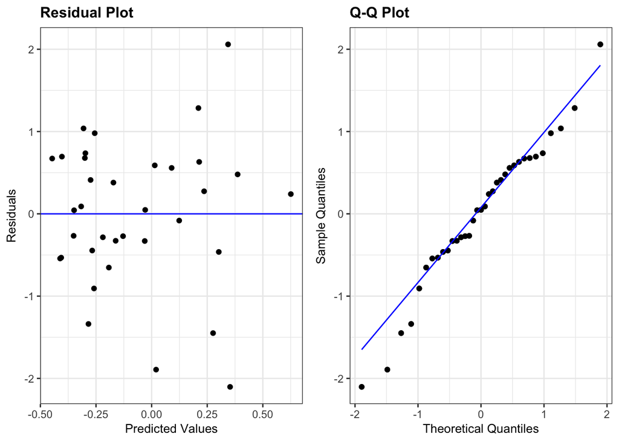

```r
resid_panel(mod.step.bfly2, plots=c("resid","qq"))
```

The scatter in the Q-Q plot is mostly straight and on the line, indicating that the residuals are normally distributed.

The scatter in the residual plot is symmetrical on either side of the 0 line, so the residuals have a mean of 0. The width of the scatter does appear slightly narrower on the left hand side of the plot than on the right hand side, indicating non-constant variance. The Breusch-Pagan test has a p-value <0.05, further supporting heteroskedacity.

```r
ncvTest(mod.step.bfly2)
```

```
## Non-constant Variance Score Test
## Variance formula: ~ fitted.values
## Chisquare = 4.75, Df = 1, p = 0.03
```

## 3.6 Write an informative conclusion

Calculate the regression coefficients and confidence intervals for the model and write your interpretations of the output. Create a plot to show the relationship between `PDSI_ALL` and `LAMBDA`.

**CHECK**

```r
summary(step.mod.blfy)
```

```
##
## Call:
## lm(formula = LAMBDA ~ PDSI_ALL, data = butterfly.df)
##
## Residuals:
##     Min      1Q  Median      3Q     Max
## -2.1027 -0.4544  0.0478  0.6100  2.0593
##
## Coefficients:
##             Estimate Std. Error t value Pr(>|t|)
## (Intercept)  -0.0134     0.1543   -0.09    0.931
## PDSI_ALL      0.1486     0.0798    1.86    0.072
##
## Residual standard error: 0.891 on 33 degrees of freedom
## Multiple R-squared:  0.095,  Adjusted R-squared:  0.0676
## F-statistic: 3.46 on 1 and 33 DF,  p-value: 0.0716
```

```r
confint(step.mod.blfy)
```

```
##               2.5 % 97.5 %
## (Intercept) -0.3274  0.301
## PDSI_ALL    -0.0138  0.311
```

A simple linear regression model containing the Palmer Drought index (`PDSI_ALL`) is a good fit for predicting change in Monarch butterfly populations (`LAMBDA`). The regression equation is:

$\hat{LAMBDA} = -0.01 + 0.15PDSI \_ ALL$

For a 1 unit increase in the Palmer drought index, change in butterfly population changes between -0.01 and 0.3.

The model explains 6.8% of the variability in Monarch butterfly change.

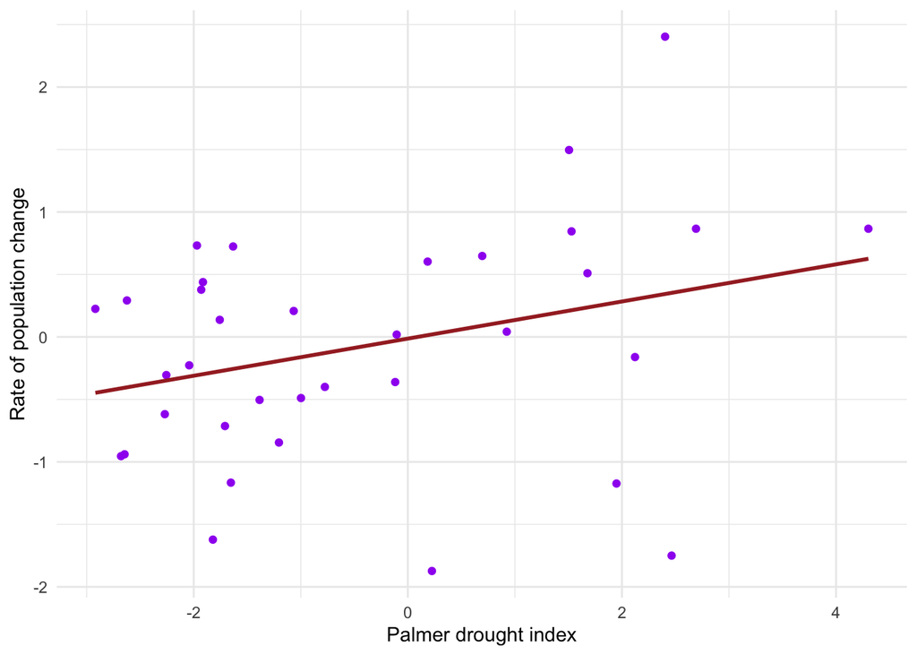

```r
ggplot(data=butterfly.df, aes(x=PDSI_ALL, y=LAMBDA))+
  geom_point(col="purple")+
  geom_smooth(method="lm", formula=y~x, col="brown", se=F)+
  labs(x="Palmer drought index", y="Rate of population change")+
  theme_minimal()
```

# 4 You’re Finished!

[figure not shown]